# SAE_Maths_Lo_Bellagraa_Final

### Première étape : Initialisation

Nous allons chercher à trouver le degré de chaque sommet et à trier les degrés par ordre décroissant des degrés.

Réutilisons les fonctions `dico_degres` et `tri_dico_degres`.

```python
# LesDegres = les degrés de grapheA
LesDegres=tri_dico_degres(dico_degres(grapheA))
print(LesDegres)
```

```
{'$x_3$': 3, '$x_1$': 2, '$x_2$': 2, '$x_4$': 2, '$x_5$': 1}
```

Nous pouvons initialiser tous les sommets en blanc.

```python
couleurs_graphe=["white" for i in range(grapheA.number_of_nodes())]
```

### Deuxième étape et troisième étape : itérations et mises à jour

```python
# 3) Itération
    # 1) choisir le DSAT le plus élevé
        # en cas d'égalité entre 2 sommets, on prend le sommet le plus à gauche
    # 2) le colorier, mais 2 sommets connectés par une arête ne doivent pas avoir la même couleur

# 4) Mise à jour
# pour remplir la ligne, on gardera le même tableau
# on regarde le nombre de sommets adjacents colorés
# si le sommet n'a pas de voisins colorés alors on garde la même valeur
# puis on répète le 3) initialisation
# on sort de la boucle lorsque tous les sommets sont coloriés
```

La fonction de l'algorithme devrait normalement fonctionner avec un seul paramètre, à savoir le graphe $G$.

```python
def algorithmeBrelaz(G):
    while (couleurs_graphe.count("white") != 0): # tant qu'il existe des sommets non coloriés
        # itérations
        # mises à jours
    return G
```

[output not shown]

Mesurons le temps d'exécution de l'algorithme avec le graphe `grapheA`

```python
tic = time()                                                    # top départ
algorithmeBrelaz(grapheA)
tac = time()                                                    # arrêt du chronomètre
print("Temps d'exécution :", round(1000*(tac-tic),2)," ms")     # Durée ms et arrondi au centième
```

[output not shown]

Animations

Nous n'avons pas terminé l'algorithme.  
Cependant, ça ne veut pas dire que nous ne pourrons pas vous montrer les animations que nous avons prévues.

### GrapheA

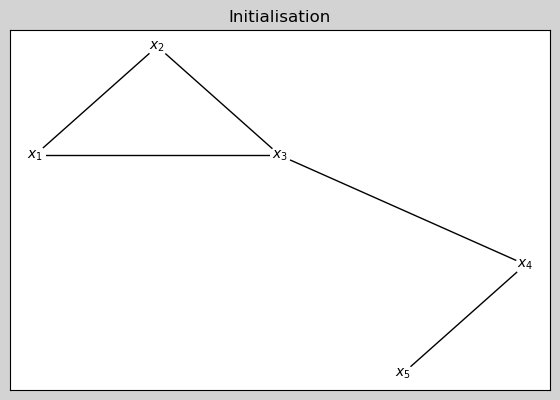

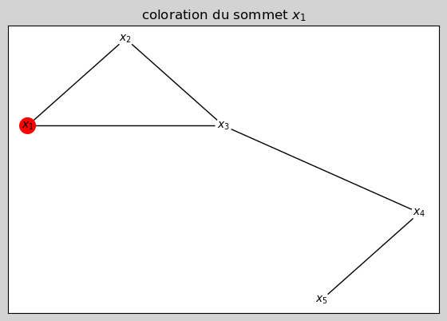

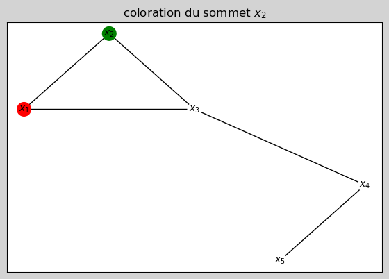

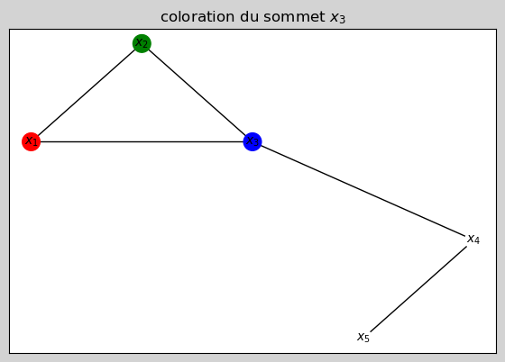

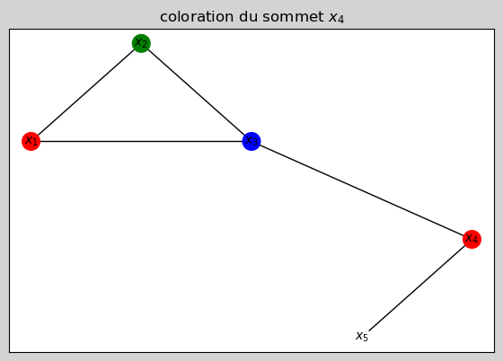

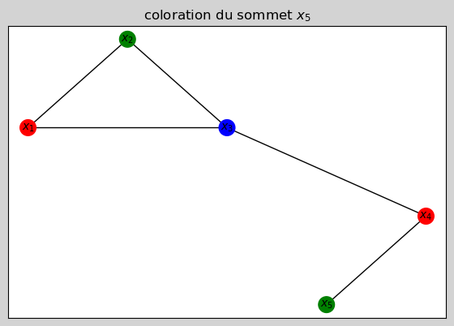

```python
# Animation
NUM_FRAME = list(grapheA.nodes)
couleurs = ["white" for i in range(grapheA.number_of_nodes())]
dessineGrapheA(grapheA, "Initialisation")
for i in range(len(NUM_FRAME)):
    if i == 0 :
        couleurs[i] = "red"
    elif i == 1:
        couleurs[i] = "green"
    elif i == 2:
        couleurs[i] = "blue"
    elif i == 3:
        couleurs[i] = "red"
    elif i == 4:
        couleurs[i] = "green"
    titre = "coloration du sommet "+str(NUM_FRAME[i])
    dessineGrapheA(grapheA, titre, couleurs)
```

### Cycle

```python
# Modification de la fonction dessineGraphe pour avoir des positions fixes pour les sommets
def dessineCycleG(graphe, titre_dessin, couleurs="white"):
    fixed_positions = {"$x_1$":(2,2), "$x_3$":(4,2), "$x_2$":(3,3)}
    fixed_nodes = fixed_positions.keys()
    pos = nx.spring_layout(graphe,pos=fixed_positions, fixed = fixed_nodes)
    fig = plt.figure(facecolor="lightgrey", dpi=100)
    ax1 = fig.add_axes([0,0,0.9,0.9])
    ax1.set_title(titre_dessin)
    nx.draw_networkx(graphe, pos, ax=ax1, arrows=None, with_labels=True, node_color=couleurs, edge_color='black', node_size=200, font_size=10)
```

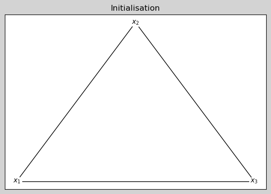

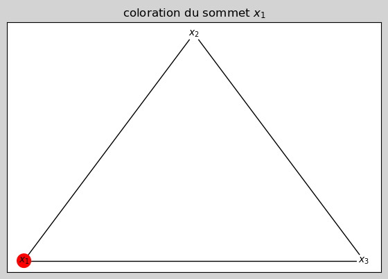

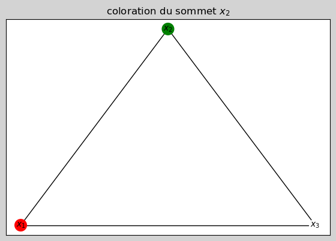

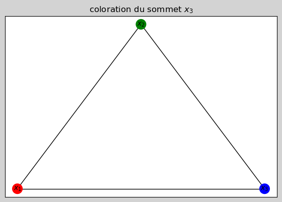

```python
# Animation
NUM_FRAME = list(cycleG.nodes)
couleurs = ["white" for i in range(cycleG.number_of_nodes())]
dessineCycleG(cycleG, "Initialisation")
for i in range(len(NUM_FRAME)):
    if i == 0 :
        couleurs[i] = "red"
    elif i == 1:
        couleurs[i] = "green"
    elif i == 2:
        couleurs[i] = "blue"
    titre = "coloration du sommet "+str(NUM_FRAME[i])
    dessineCycleG(cycleG, titre, couleurs)
```

Nous aurions ainsi pu démontrer que : $X(Z_n)=3$ lorsque le nombre de sommets est impair

Crééons un cycle à 4 sommets :

```python
# Modification de la fonction dessineGraphe pour avoir des positions fixes pour les sommets
def dessineCycle4(graphe, titre_dessin, couleurs="white"):
    fixed_positions = {"$x_1$":(1,1), "$x_3$":(3,1), "$x_2$":(2,2), "$x_4$":(2,0)}
    fixed_nodes = fixed_positions.keys()
    pos = nx.spring_layout(graphe,pos=fixed_positions, fixed = fixed_nodes)
    fig = plt.figure(facecolor="lightgrey", dpi=100)
    ax1 = fig.add_axes([0,0,0.9,0.9])
    ax1.set_title(titre_dessin)
    nx.draw_networkx(graphe, pos, ax=ax1, arrows=None, with_labels=True, node_color=couleurs, edge_color='black', node_size=200, font_size=10)
```

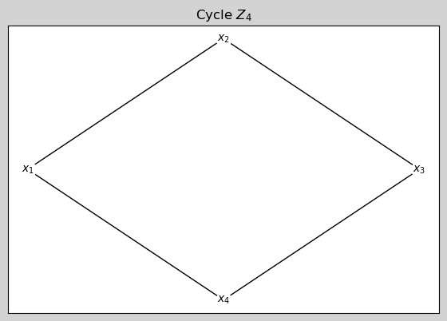

```python
cycle4 = nx.cycle_graph(4)
cycle4 = nx.relabel_nodes(cycle4, {0: '$x_1$', 1: '$x_2$', 2: '$x_3$', 3: '$x_4$'})
dessineCycle4(cycle4, "Cycle $Z_4$")
```

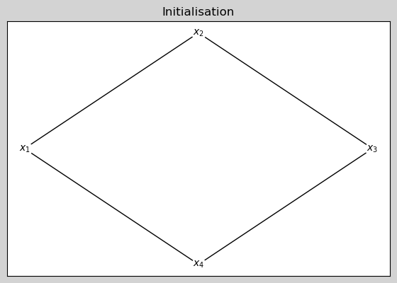

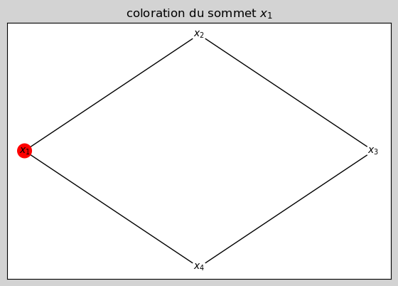

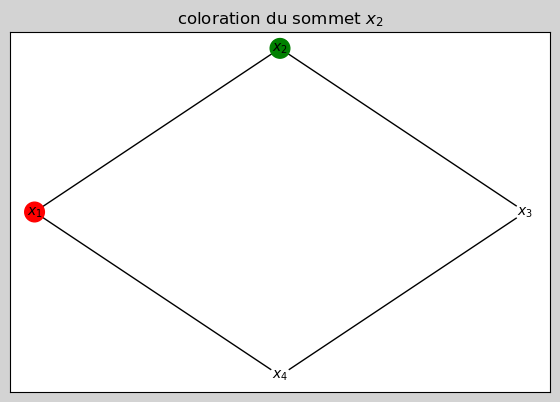

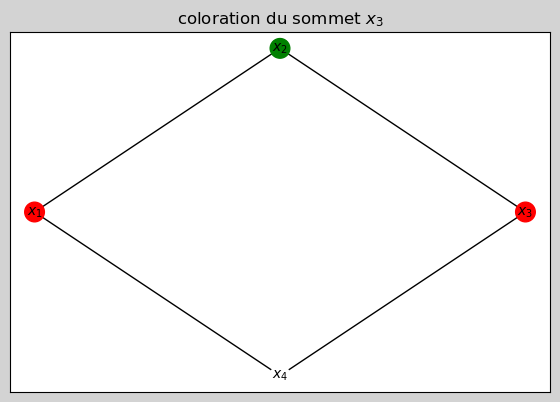

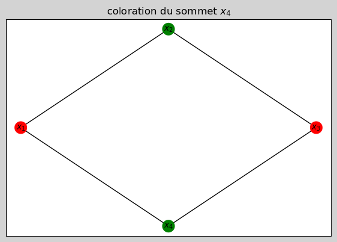

```python
# Animation
NUM_FRAME = list(cycle4.nodes)
couleurs = ["white" for i in range(cycle4.number_of_nodes())]
dessineCycle4(cycle4, "Initialisation")
for i in range(len(NUM_FRAME)):
    if i == 0 :
        couleurs[i] = "red"
    elif i == 1:
        couleurs[i] = "green"
    elif i == 2:
        couleurs[i] = "red"
    elif i == 3:
        couleurs[i] = "green"
    titre = "coloration du sommet "+str(NUM_FRAME[i])
    dessineCycle4(cycle4, titre, couleurs)
```

Nous aurions ainsi pu démontrer que : $X(Z_n)=2$ lorsque le nombre de sommets est pair

### Clique

```python
# Modification de la fonction dessineGraphe pour avoir des positions fixes pour les sommets
def dessineClique5(graphe, titre_dessin, couleurs="white"):
    fixed_positions = {"$x_1$":(1,1), "$x_3$":(4,2), "$x_2$":(2,2), "$x_4$":(5,1), "$x_5$":(3,0)}
    fixed_nodes = fixed_positions.keys()
    pos = nx.spring_layout(graphe,pos=fixed_positions, fixed = fixed_nodes)
    fig = plt.figure(facecolor="lightgrey", dpi=100)
    ax1 = fig.add_axes([0,0,0.9,0.9])
    ax1.set_title(titre_dessin)
    nx.draw_networkx(graphe, pos, ax=ax1, arrows=None, with_labels=True, node_color=couleurs, edge_color='black', node_size=200, font_size=10)
```

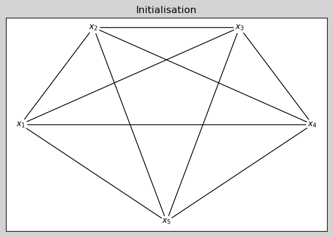

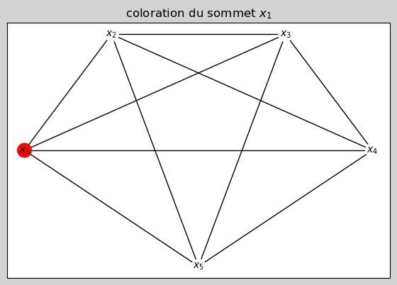

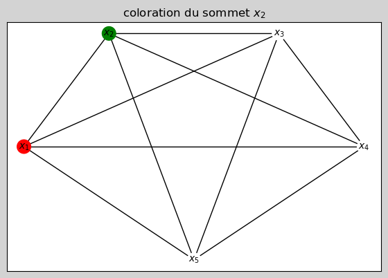

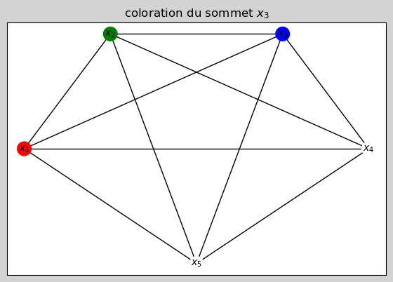

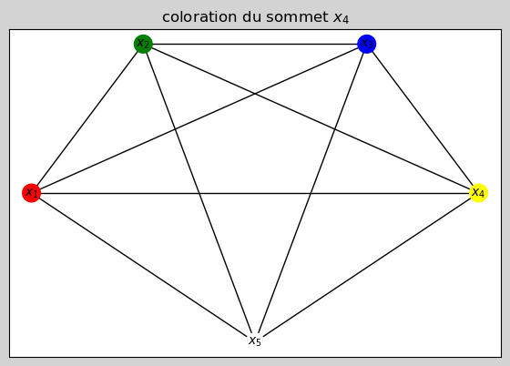

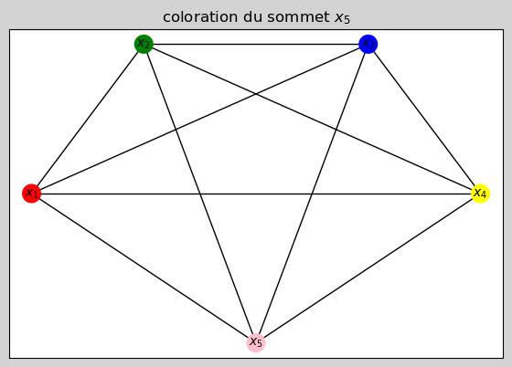

```python
# Animation
NUM_FRAME = list(cliqueG.nodes)
couleurs = ["white" for i in range(cliqueG.number_of_nodes())]
dessineClique5(cliqueG, "Initialisation")
for i in range(len(NUM_FRAME)):
    if i == 0 :
        couleurs[i] = "red"
    elif i == 1:
        couleurs[i] = "green"
    elif i == 2:
        couleurs[i] = "blue"
    elif i == 3:
        couleurs[i] = "yellow"
    elif i == 4:
        couleurs[i] = "pink"
    titre = "coloration du sommet "+str(NUM_FRAME[i])
    dessineClique5(cliqueG, titre, couleurs)
```

Nous aurions ainsi pu démontrer que : $X(K_n)=n$